# Intuition pour la transformée de Fourier et la convolution

Ce notebook privilégie les **images mentales**, les **expériences numériques** et les liens entre les deux notions.

## Objectifs

À la fin, on doit pouvoir retenir que :

1. la transformée de Fourier décrit un signal comme une somme d'oscillations ;
2. une translation modifie surtout la **phase**, pas le contenu fréquentiel ;
3. localiser un signal dans le temps étale son spectre ;
4. la convolution fait glisser un motif sur un autre et mesure leur recouvrement ;
5. **convoluer dans le temps revient à multiplier en fréquence**.

Nous travaillerons avec des signaux échantillonnés, donc avec la transformée de Fourier discrète (DFT), calculée par la FFT.

## 0. Outils et conventions numériques

Pour des échantillons $x_0,\dots,x_{N-1}$, NumPy calcule

$$ X_k=\sum_{n=0}^{N-1}x_n e^{-2i\pi kn/N}. $$

On affichera généralement le **spectre d'amplitude bilatéral** $|X_k|/N$. Pour un cosinus réel d'amplitude $A$, on voit deux pics de hauteur $A/2$, aux fréquences $+f_0$ et $-f_0$.

```python
import numpy as np
import matplotlib.pyplot as plt
from scipy import signal
from scipy.ndimage import convolve as convolve2d

rng = np.random.default_rng(2026)
plt.rcParams.update({
    "figure.figsize": (11, 4),
    "axes.grid": True,
    "grid.alpha": 0.25,
    "font.size": 11,
})

def spectrum(x, fs):
    """Fréquences centrées et DFT centrée, avec normalisation 1/N."""
    x = np.asarray(x)
    X = np.fft.fftshift(np.fft.fft(x)) / len(x)
    f = np.fft.fftshift(np.fft.fftfreq(len(x), d=1/fs))
    return f, X

def plot_signal_and_spectrum(t, x, fs, title, fmax=None):
    f, X = spectrum(x, fs)
    fig, ax = plt.subplots(1, 2, figsize=(12, 3.8))
    ax[0].plot(t, x, lw=1.5)
    ax[0].set(xlabel="temps (s)", ylabel="amplitude", title=title)
    ax[1].plot(f, np.abs(X), lw=1.4)
    if fmax is not None:
        ax[1].set_xlim(-fmax, fmax)
    ax[1].set(xlabel="fréquence (Hz)", ylabel=r"$|X(f)|$", title="Spectre d'amplitude")
    plt.tight_layout()
    plt.show()

print("Bibliothèques chargées ; générateur aléatoire fixé pour la reproductibilité.")
```

```
Bibliothèques chargées ; générateur aléatoire fixé pour la reproductibilité.
```

# Partie I — Voir un signal avec les lunettes de Fourier

## Exemple 1 — Une sinusoïde pure donne deux pics

Le cosinus s'écrit

$$ \cos(2\pi f_0t)=\frac12e^{2i\pi f_0t}+\frac12e^{-2i\pi f_0t}. $$

Le spectre bilatéral contient donc deux fréquences opposées. C'est le cas le plus simple : une seule « couleur sonore ».

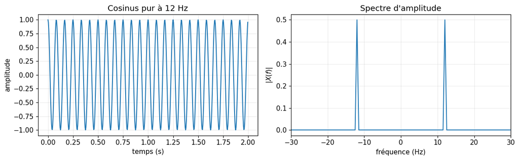

```python
fs = 256
T = 2
t = np.arange(0, T, 1/fs)
f0 = 12
x = np.cos(2*np.pi*f0*t)
plot_signal_and_spectrum(t, x, fs, "Cosinus pur à 12 Hz", fmax=30)
```

## Exemple 2 — Une somme de sons donne une somme de pics

La transformée de Fourier est linéaire :

$$ \mathcal F(af+bg)=a\widehat f+b\widehat g. $$

Une courbe temporelle compliquée peut donc avoir une description fréquentielle très simple.

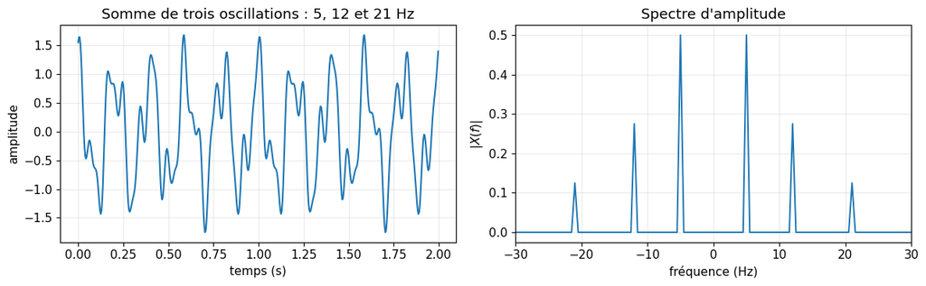

```python
x = (1.0*np.cos(2*np.pi*5*t)
     + 0.55*np.cos(2*np.pi*12*t)
     + 0.25*np.sin(2*np.pi*21*t))
plot_signal_and_spectrum(t, x, fs, "Somme de trois oscillations : 5, 12 et 21 Hz", fmax=30)
```

## Exemple 3 — La phase code la position

Décaler $f$ de $\tau$ multiplie sa transformée par une phase :

$$ \mathcal F(f(\cdot-\tau))(\xi)=e^{-2i\pi\xi\tau}\widehat f(\xi). $$

Le module ne change pas. Deux signaux peuvent donc avoir **exactement le même spectre d'amplitude** tout en étant décalés.

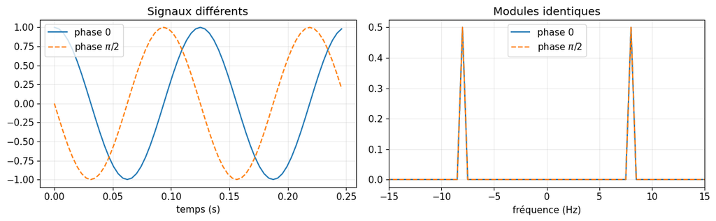

```
Écart maximal entre les deux spectres d'amplitude : 9.415246148577693e-16
```

```python
x1 = np.cos(2*np.pi*8*t)
x2 = np.cos(2*np.pi*8*t + np.pi/2)
f, X1 = spectrum(x1, fs)
_, X2 = spectrum(x2, fs)

fig, ax = plt.subplots(1, 2, figsize=(12, 3.8))
ax[0].plot(t[:64], x1[:64], label="phase 0")
ax[0].plot(t[:64], x2[:64], "--", label=r"phase $\pi/2$")
ax[0].set(title="Signaux différents", xlabel="temps (s)"); ax[0].legend()
ax[1].plot(f, np.abs(X1), label="phase 0")
ax[1].plot(f, np.abs(X2), "--", label=r"phase $\pi/2$")
ax[1].set(xlim=(-15, 15), title="Modules identiques", xlabel="fréquence (Hz)")
ax[1].legend(); plt.tight_layout(); plt.show()
print("Écart maximal entre les deux spectres d'amplitude :", np.max(np.abs(np.abs(X1)-np.abs(X2))))
```

## Exemple 4 — Reconstituer un signal avec quelques fréquences

Un signal périodique peut être approché par une somme de sinusoïdes. Pour un créneau, seules les harmoniques impaires interviennent :

$$ s_M(t)=\frac4\pi\sum_{m=0}^{M-1}\frac{\sin(2\pi(2m+1)t)}{2m+1}. $$

Les oscillations près des discontinuités illustrent le **phénomène de Gibbs** : ajouter des fréquences affine le saut sans supprimer complètement le dépassement.

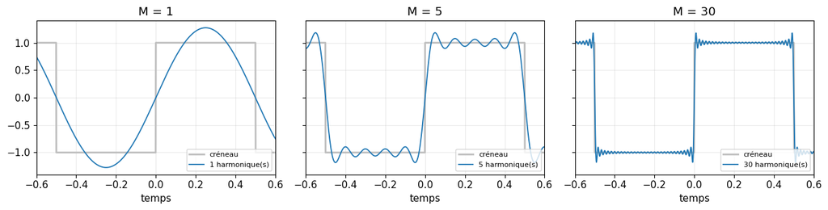

```python
tp = np.linspace(-1, 1, 2000, endpoint=False)
target = np.where(np.sin(2*np.pi*tp) >= 0, 1.0, -1.0)
fig, axes = plt.subplots(1, 3, figsize=(13, 3.4), sharey=True)
for ax, M in zip(axes, [1, 5, 30]):
    approx = sum(np.sin(2*np.pi*(2*m+1)*tp)/(2*m+1) for m in range(M))*4/np.pi
    ax.plot(tp, target, color="0.75", lw=2, label="créneau")
    ax.plot(tp, approx, lw=1.3, label=f"{M} harmonique(s)")
    ax.set(title=f"M = {M}", xlabel="temps", xlim=(-0.6, 0.6))
    ax.legend(loc="lower right", fontsize=8)
plt.tight_layout(); plt.show()
```

## Exemple 5 — Battements : deux fréquences proches

Deux cosinus de fréquences proches produisent une enveloppe lente :

$$ \cos(2\pi f_1t)+\cos(2\pi f_2t) =2\cos(\pi(f_1-f_2)t)\cos(\pi(f_1+f_2)t). $$

Dans le temps on voit des battements ; en fréquence on voit simplement deux raies.

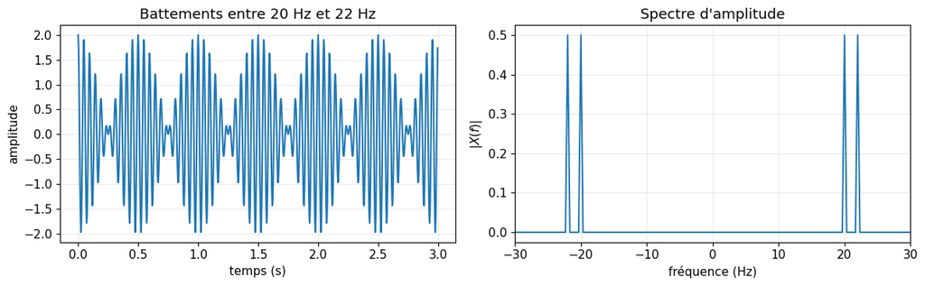

```python
tb = np.arange(0, 3, 1/fs)
xb = np.cos(2*np.pi*20*tb) + np.cos(2*np.pi*22*tb)
plot_signal_and_spectrum(tb, xb, fs, "Battements entre 20 Hz et 22 Hz", fmax=30)
```

## Exemple 6 — Repliement spectral (aliasing)

Avec une fréquence d'échantillonnage $f_s$, les fréquences au-delà de $f_s/2$ deviennent ambiguës. Par exemple, à $f_s=40$ Hz, une oscillation à 27 Hz donne les mêmes échantillons qu'une oscillation à $27-40=-13$ Hz.

C'est pourquoi on filtre les hautes fréquences **avant** d'échantillonner.

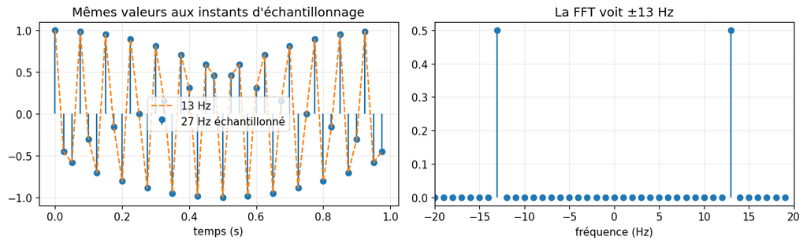

```
Erreur maximale entre les échantillons : 2.3148150063434514e-14
```

```python
fs_alias = 40
ta = np.arange(0, 1, 1/fs_alias)
xa = np.cos(2*np.pi*27*ta)
xa_alias = np.cos(2*np.pi*13*ta)
fig, ax = plt.subplots(1, 2, figsize=(12, 3.7))
ax[0].stem(ta, xa, basefmt=" ", label="27 Hz échantillonné")
ax[0].plot(ta, xa_alias, "C1--", label="13 Hz")
ax[0].set(title="Mêmes valeurs aux instants d'échantillonnage", xlabel="temps (s)")
ax[0].legend()
f, Xa = spectrum(xa, fs_alias)
ax[1].stem(f, np.abs(Xa), basefmt=" ")
ax[1].set(title="La FFT voit ±13 Hz", xlabel="fréquence (Hz)", xlim=(-20, 20))
plt.tight_layout(); plt.show()
print("Erreur maximale entre les échantillons :", np.max(np.abs(xa-xa_alias)))
```

## Exemple 7 — Localisation et principe d'incertitude

Une gaussienne étroite dans le temps a un spectre large ; une gaussienne large a un spectre étroit. Schématiquement :

$$ \text{précision temporelle}\times\text{précision fréquentielle}\gtrsim\text{constante}. $$

On ne peut pas être arbitrairement localisé dans les deux domaines.

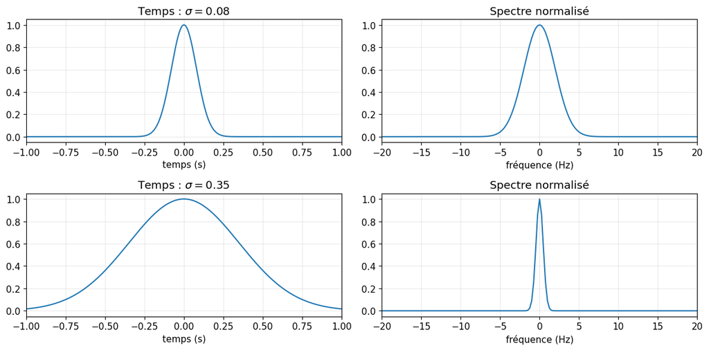

```python
fs_g = 500
tg = np.arange(-2, 2, 1/fs_g)
fig, axes = plt.subplots(2, 2, figsize=(12, 6))
for row, sigma in enumerate([0.08, 0.35]):
    g = np.exp(-tg**2/(2*sigma**2))
    f, G = spectrum(g, fs_g)
    axes[row, 0].plot(tg, g)
    axes[row, 0].set(xlim=(-1, 1), title=fr"Temps : $\sigma={sigma}$")
    axes[row, 1].plot(f, np.abs(G)/np.max(np.abs(G)))
    axes[row, 1].set(xlim=(-20, 20), title="Spectre normalisé")
for ax in axes[:,0]: ax.set_xlabel("temps (s)")
for ax in axes[:,1]: ax.set_xlabel("fréquence (Hz)")
plt.tight_layout(); plt.show()
```

## Exemple 8 — Une impulsion courte contient beaucoup de fréquences

Un clic très bref doit mobiliser une large gamme de fréquences. À l'inverse, un son long et régulier produit un pic spectral fin. La largeur d'un lobe spectral est approximativement inverse de la durée de l'observation.

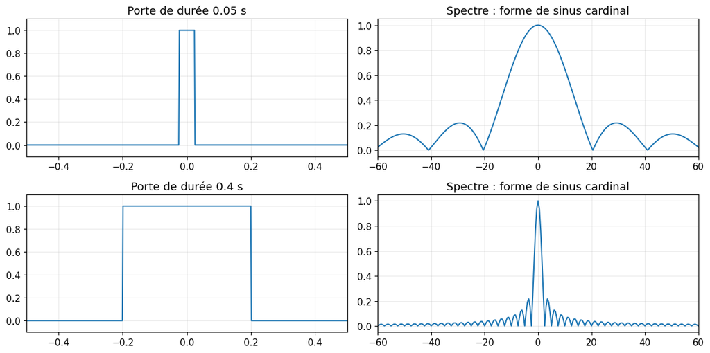

```python
fs_p = 512
tp = np.arange(-1, 1, 1/fs_p)
fig, axes = plt.subplots(2, 2, figsize=(12, 6))
for row, width in enumerate([0.05, 0.4]):
    pulse = (np.abs(tp) <= width/2).astype(float)
    f, P = spectrum(pulse, fs_p)
    axes[row,0].plot(tp, pulse)
    axes[row,0].set(xlim=(-0.5,0.5), ylim=(-0.1,1.1), title=f"Porte de durée {width} s")
    axes[row,1].plot(f, np.abs(P)/np.max(np.abs(P)))
    axes[row,1].set(xlim=(-60,60), title="Spectre : forme de sinus cardinal")
plt.tight_layout(); plt.show()
```

# Partie II — La convolution comme recouvrement glissant

Pour des fonctions intégrables,

$$ (f*g)(x)=\int_{\mathbb R}f(t)g(x-t)\,dt. $$

Pour comprendre la formule à un point $x$ :

1. retourner $g$ : $t\mapsto g(-t)$ ;
2. la déplacer de $x$ : $t\mapsto g(x-t)$ ;
3. multiplier avec $f$ ;
4. intégrer le recouvrement.

En discret, l'intégrale devient une somme : $(x*h)[n]=\sum_k x[k]h[n-k]$.

## Exemple 9 — Deux portes donnent un triangle

Quand une porte glisse sur une autre, la convolution mesure la longueur de leur intersection. Cette longueur croît linéairement, atteint un maximum, puis décroît : on obtient un triangle.

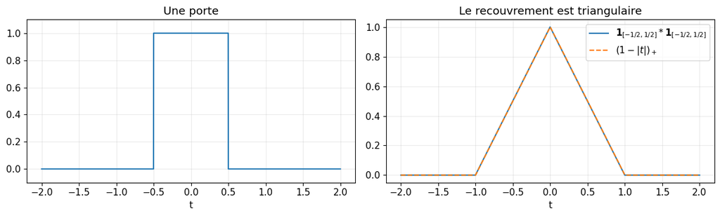

```python
dt = 0.002
tc = np.arange(-2, 2+dt, dt)
box = (np.abs(tc) <= 0.5).astype(float)
tri = signal.convolve(box, box, mode="same") * dt
fig, ax = plt.subplots(1, 2, figsize=(12, 3.7))
ax[0].plot(tc, box)
ax[0].set(title="Une porte", xlabel="t", ylim=(-0.1,1.1))
ax[1].plot(tc, tri, label=r"$\mathbf{1}_{[-1/2,1/2]}*\mathbf{1}_{[-1/2,1/2]}$")
ax[1].plot(tc, np.maximum(1-np.abs(tc),0), "--", label=r"$(1-|t|)_+$")
ax[1].set(title="Le recouvrement est triangulaire", xlabel="t")
ax[1].legend(); plt.tight_layout(); plt.show()
```

## Exemple 10 — Le Dirac est l'élément neutre et transporte les signaux

Formellement,

$$ f*\delta=f,\qquad f*\delta_a=f(\cdot-a). $$

En discret, un tableau nul avec un unique coefficient égal à 1 joue le rôle d'une masse de Dirac. Une réponse impulsionnelle composée de plusieurs Dirac produit des copies retardées : c'est le principe d'un écho.

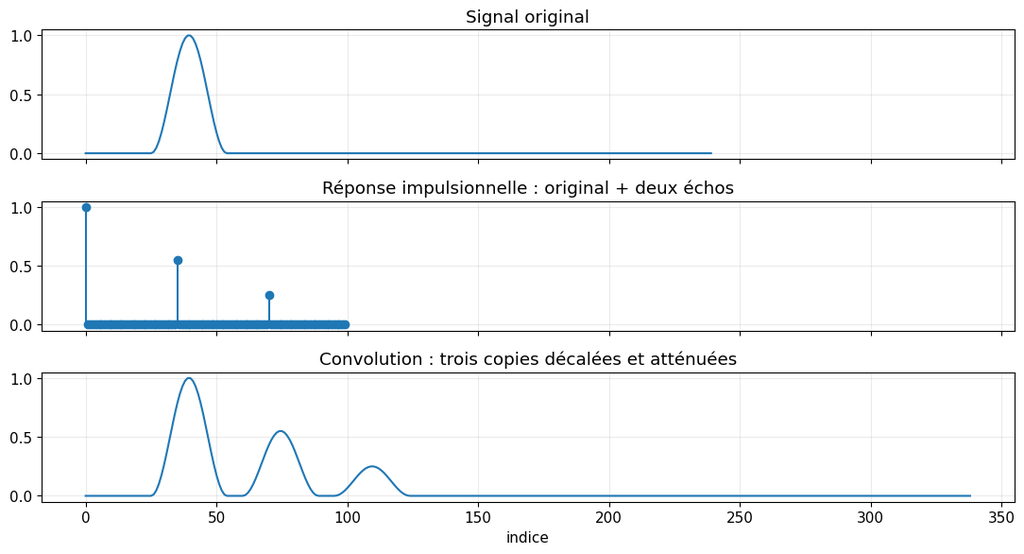

```python
n = 240
x = np.zeros(n)
x[25:55] = signal.windows.hann(30)
h = np.zeros(100)
h[0], h[35], h[70] = 1.0, 0.55, 0.25
y = signal.convolve(x, h, mode="full")
fig, ax = plt.subplots(3, 1, figsize=(11, 6), sharex=True)
ax[0].plot(x); ax[0].set_title("Signal original")
ax[1].stem(h, basefmt=" "); ax[1].set_title("Réponse impulsionnelle : original + deux échos")
ax[2].plot(y); ax[2].set_title("Convolution : trois copies décalées et atténuées")
ax[2].set_xlabel("indice")
plt.tight_layout(); plt.show()
```

## Exemple 11 — Moyenne glissante = convolution = lissage

Le noyau

$$ h[k]=\frac1m\mathbf 1_{\{0,\ldots,m-1\}}(k) $$

remplace chaque valeur par une moyenne locale. Les variations rapides et le bruit s'annulent partiellement : c'est un **filtre passe-bas**.

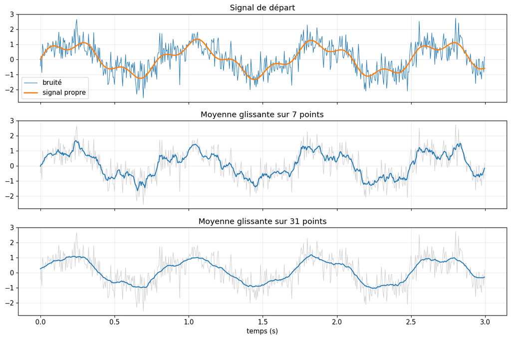

```python
fs_n = 200
tn = np.arange(0, 3, 1/fs_n)
clean = np.sin(2*np.pi*1.2*tn) + 0.35*np.sin(2*np.pi*4*tn)
noisy = clean + 0.55*rng.normal(size=len(tn))
fig, axes = plt.subplots(3, 1, figsize=(12, 8), sharex=True)
axes[0].plot(tn, noisy, lw=0.8, label="bruité")
axes[0].plot(tn, clean, lw=2, label="signal propre")
axes[0].legend(); axes[0].set_title("Signal de départ")
for ax, m in zip(axes[1:], [7, 31]):
    h = np.ones(m)/m
    smooth = signal.convolve(noisy, h, mode="same")
    ax.plot(tn, noisy, color="0.8", lw=0.7)
    ax.plot(tn, smooth, lw=1.5)
    ax.set_title(f"Moyenne glissante sur {m} points")
axes[-1].set_xlabel("temps (s)")
plt.tight_layout(); plt.show()
```

## Exemple 12 — Dériver par convolution

Attention : selon la convention de convolution, le signe peut être opposé à celui d'une corrélation avec le même masque.

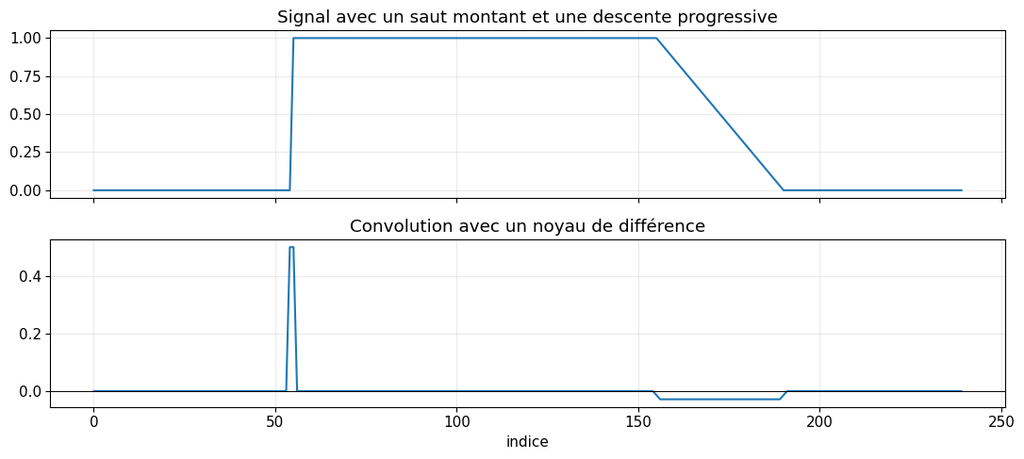

```python
x = np.zeros(240)
x[55:155] = 1
x[155:190] = np.linspace(1, 0, 35, endpoint=False)
derivative_kernel = np.array([1, 0, -1])/2
edge = signal.convolve(x, derivative_kernel, mode="same")
fig, ax = plt.subplots(2, 1, figsize=(11, 5), sharex=True)
ax[0].plot(x); ax[0].set_title("Signal avec un saut montant et une descente progressive")
ax[1].plot(edge); ax[1].axhline(0, color="k", lw=0.7)
ax[1].set_title("Convolution avec un noyau de différence")
ax[1].set_xlabel("indice")
plt.tight_layout(); plt.show()
```

# Partie III — Le pont fondamental

## Théorème de convolution

Sous des hypothèses adaptées,

$$ \boxed{\mathcal F(f*g)=\widehat f\,\widehat g} \qquad\text{et}\qquad \boxed{\mathcal F(fg)=\widehat f*\widehat g}. $$

### Intuition « valeurs propres »

Les exponentielles $e^{2i\pi\xi t}$ sont les briques élémentaires de Fourier. Un système invariant par translation — donc une convolution par $h$ — ne change pas leur forme :

$$ (h*e^{2i\pi\xi\cdot})(t)=\widehat h(\xi)e^{2i\pi\xi t}. $$

Chaque fréquence est simplement multipliée par un nombre complexe $\widehat h(\xi)$. La convolution, compliquée dans le temps, devient donc une multiplication diagonale en fréquence.

## Exemple 13 — Vérification numérique du théorème

Pour la convolution linéaire discrète, on complète les deux tableaux par des zéros jusqu'à la longueur $N+M-1$. On compare ensuite la convolution directe et l'FFT inverse du produit des FFT.

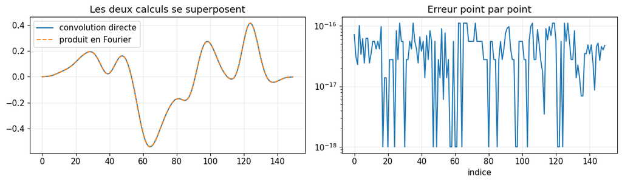

```
Erreur maximale : 1.110e-16
```

```python
x = rng.normal(size=120)
h = signal.windows.gaussian(31, std=5)
h /= h.sum()
y_direct = signal.convolve(x, h, mode="full")
L = len(x) + len(h) - 1
y_fourier = np.fft.ifft(np.fft.fft(x, L)*np.fft.fft(h, L)).real
err = np.max(np.abs(y_direct-y_fourier))

fig, ax = plt.subplots(1, 2, figsize=(12, 3.6))
ax[0].plot(y_direct, label="convolution directe")
ax[0].plot(y_fourier, "--", label="produit en Fourier")
ax[0].set_title("Les deux calculs se superposent"); ax[0].legend()
ax[1].semilogy(np.maximum(np.abs(y_direct-y_fourier), 1e-18))
ax[1].set_title("Erreur point par point"); ax[1].set_xlabel("indice")
plt.tight_layout(); plt.show()
print(f"Erreur maximale : {err:.3e}")
assert err < 1e-10
```

## Exemple 14 — Comprendre le filtre moyenneur dans les deux domaines

Une moyenne locale étale une valeur dans le temps. En fréquence, sa transformée est grande près de 0 et petite aux hautes fréquences : elle conserve les variations lentes et atténue les rapides.

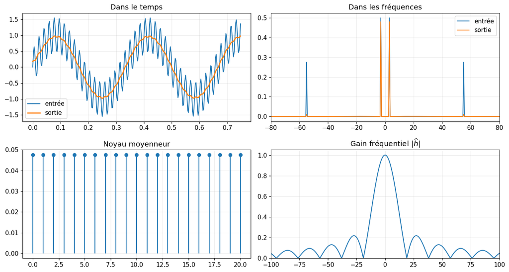

```python
fs_f = 400
tf = np.arange(0, 2, 1/fs_f)
low = np.sin(2*np.pi*3*tf)
high = 0.55*np.sin(2*np.pi*55*tf)
x = low + high
m = 21
h = np.ones(m)/m
y = signal.convolve(x, h, mode="same")

f, X = spectrum(x, fs_f)
_, Y = spectrum(y, fs_f)
H = np.fft.fftshift(np.fft.fft(h, len(x)))
fig, ax = plt.subplots(2, 2, figsize=(13, 7))
ax[0,0].plot(tf[:300], x[:300], label="entrée")
ax[0,0].plot(tf[:300], y[:300], label="sortie", lw=2)
ax[0,0].set_title("Dans le temps"); ax[0,0].legend()
ax[0,1].plot(f, np.abs(X), label="entrée")
ax[0,1].plot(f, np.abs(Y), label="sortie")
ax[0,1].set(xlim=(-80,80), title="Dans les fréquences"); ax[0,1].legend()
ax[1,0].stem(np.arange(m), h, basefmt=" ")
ax[1,0].set_title("Noyau moyenneur")
ax[1,1].plot(f, np.abs(H))
ax[1,1].set(xlim=(-100,100), ylim=(0,1.05), title=r"Gain fréquentiel $|\widehat h|$")
plt.tight_layout(); plt.show()
```

## Exemple 15 — Flou et détection de contours sur une image

Une image est un signal à deux variables. Une convolution 2D par :

- un noyau positif de masse 1 produit un flou local ;
- un noyau de différences détecte les variations rapides, donc les contours.

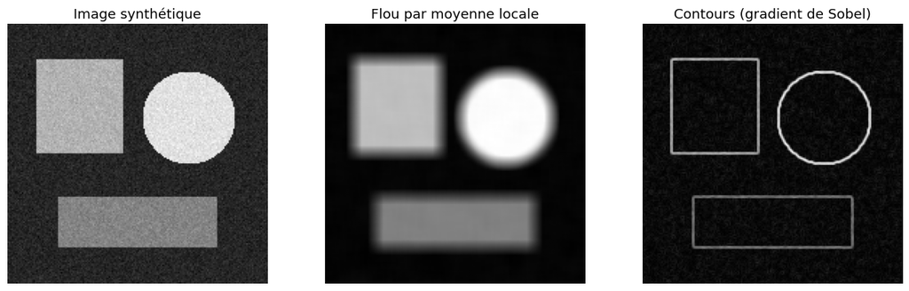

```python
N = 180
img = np.zeros((N, N))
img[25:90, 20:80] = 0.75
yy, xx = np.mgrid[:N, :N]
img[(xx-125)**2 + (yy-65)**2 < 32**2] = 1.0
img[120:155, 35:145] = 0.5
img += 0.05*rng.normal(size=img.shape)

blur_kernel = np.ones((11, 11))/121
sobel_x = np.array([[-1,0,1],[-2,0,2],[-1,0,1]])
sobel_y = sobel_x.T
blurred = convolve2d(img, blur_kernel, mode="reflect")
gx = convolve2d(img, sobel_x, mode="reflect")
gy = convolve2d(img, sobel_y, mode="reflect")
edges = np.hypot(gx, gy)

fig, axes = plt.subplots(1, 3, figsize=(13, 4))
for ax, data, title in zip(axes, [img, blurred, edges], ["Image synthétique", "Flou par moyenne locale", "Contours (gradient de Sobel)"]):
    ax.imshow(data, cmap="gray")
    ax.set_title(title); ax.axis("off")
plt.tight_layout(); plt.show()
```

## Exemple 16 — Convolution ou corrélation ?

La corrélation

$$ C[k]=\sum_n x[n]g[n+k] $$

fait glisser un motif **sans le retourner** et sert à le localiser. La convolution retourne le noyau. Pour un noyau symétrique, elles coïncident ; sinon, il faut distinguer les deux.

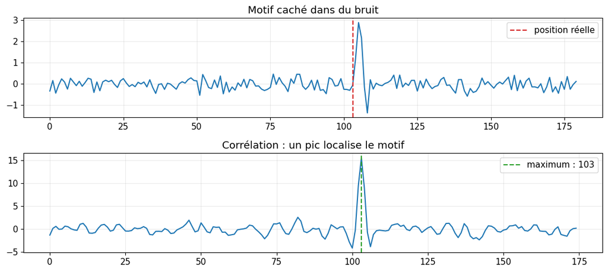

```
Position réelle : 103; position estimée : 103
```

```python
pattern = np.array([0, 1, 3, 2, 0, -1.0])
x = 0.25*rng.normal(size=180)
true_position = 103
x[true_position:true_position+len(pattern)] += pattern
corr = signal.correlate(x, pattern, mode="valid")
estimated = int(np.argmax(corr))

fig, ax = plt.subplots(2, 1, figsize=(11, 5), sharex=False)
ax[0].plot(x); ax[0].axvline(true_position, color="C3", ls="--", label="position réelle")
ax[0].set_title("Motif caché dans du bruit"); ax[0].legend()
ax[1].plot(corr); ax[1].axvline(estimated, color="C2", ls="--", label=f"maximum : {estimated}")
ax[1].set_title("Corrélation : un pic localise le motif"); ax[1].legend()
plt.tight_layout(); plt.show()
print(f"Position réelle : {true_position}; position estimée : {estimated}")
assert estimated == true_position
```

# Partie IV — Trois pièges numériques importants

## 1. Fuite spectrale

La FFT traite le bloc observé comme une période d'un signal périodique. Si le bloc ne contient pas un nombre entier de périodes, ses extrémités se raccordent mal : l'énergie « fuit » vers les fréquences voisines. Une fenêtre de Hann adoucit le raccord, au prix d'un pic principal plus large.

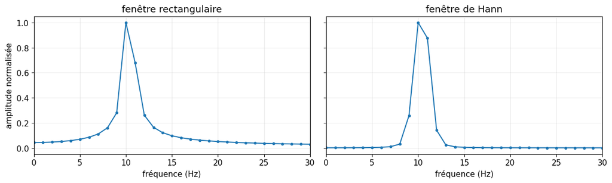

```python
fs_l = 128
N = 128
tl = np.arange(N)/fs_l
xl = np.cos(2*np.pi*10.4*tl)
windows = {"fenêtre rectangulaire": np.ones(N), "fenêtre de Hann": signal.windows.hann(N)}
fig, ax = plt.subplots(1, 2, figsize=(12, 3.7), sharey=True)
for a, (name, w) in zip(ax, windows.items()):
    f = np.fft.rfftfreq(N, 1/fs_l)
    X = np.abs(np.fft.rfft(xl*w))
    a.plot(f, X/X.max(), marker="o", ms=3)
    a.set(xlim=(0,30), xlabel="fréquence (Hz)", title=name)
ax[0].set_ylabel("amplitude normalisée")
plt.tight_layout(); plt.show()
```

## 2. Convolution circulaire

Multiplier deux FFT **sans compléter par des zéros** calcule une convolution circulaire : ce qui dépasse à droite revient à gauche. Pour retrouver la convolution linéaire de deux tableaux de tailles $N$ et $M$, il faut une FFT d'au moins $N+M-1$ points.

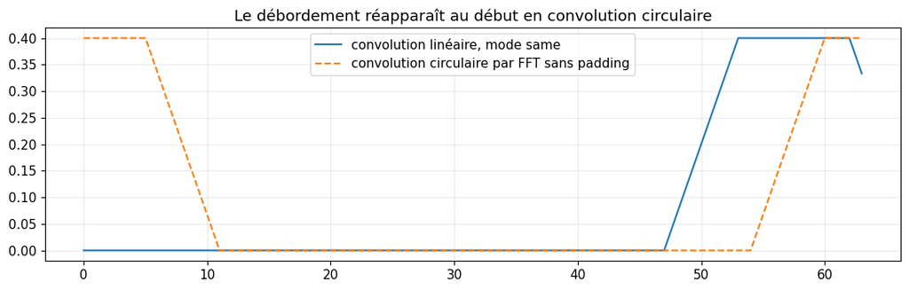

```python
x = np.zeros(64); x[55:61] = 1
h = np.ones(15)/15
circular = np.fft.ifft(np.fft.fft(x)*np.fft.fft(h, len(x))).real
linear_same = signal.convolve(x, h, mode="same")
fig, ax = plt.subplots(figsize=(11,3.6))
ax.plot(linear_same, label="convolution linéaire, mode same")
ax.plot(circular, "--", label="convolution circulaire par FFT sans padding")
ax.set_title("Le débordement réapparaît au début en convolution circulaire")
ax.legend(); plt.tight_layout(); plt.show()
```

## 3. Le module ne suffit pas

Le spectre d'amplitude dit **combien** de chaque fréquence est présente ; la phase dit **comment elles sont alignées**. Une reconstruction avec les bons modules mais des phases aléatoires peut être méconnaissable.

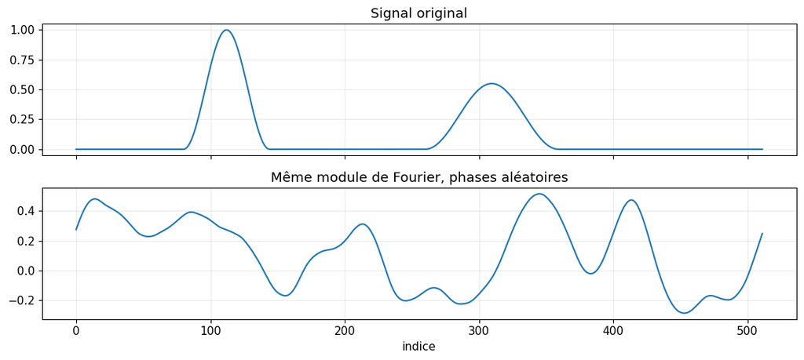

```
Écart entre les modules : 7.105427357601002e-15
```

```python
N = 512
x = np.zeros(N)
x[80:145] = signal.windows.hann(65)
x[260:360] = 0.55*signal.windows.hann(100)
X = np.fft.rfft(x)
random_phase = rng.uniform(-np.pi, np.pi, size=len(X))
random_phase[0] = 0
if N % 2 == 0: random_phase[-1] = 0
x_random_phase = np.fft.irfft(np.abs(X)*np.exp(1j*random_phase), n=N)
fig, ax = plt.subplots(2, 1, figsize=(11,5), sharex=True)
ax[0].plot(x); ax[0].set_title("Signal original")
ax[1].plot(x_random_phase); ax[1].set_title("Même module de Fourier, phases aléatoires")
ax[1].set_xlabel("indice")
plt.tight_layout(); plt.show()
print("Écart entre les modules :", np.max(np.abs(np.abs(np.fft.rfft(x_random_phase))-np.abs(X))))
```

# Partie V — Exercices progressifs

Les dix exercices sont classés en trois niveaux. Pour travailler réellement :

1. lire l'énoncé sans ouvrir l'indication ;
2. écrire la solution dans la cellule « Votre solution ici » ;
3. exécuter la cellule et interpréter le résultat ;
4. comparer ensuite avec le corrigé regroupé plus bas.

Les cellules de corrigé sont autonomes autant que possible et comportent des vérifications numériques avec `assert`.

## Exercice 1 — Retrouver les composantes d'un signal ★

On considère

$$x(t)=1{,}4\cos(2\pi\,7t)+0{,}8\sin(2\pi\,19t)+0{,}35\cos(2\pi\,31t).$$

1. Échantillonner ce signal à 256 Hz pendant 2 secondes.
2. Calculer son spectre.
3. Retrouver automatiquement les trois fréquences positives et leurs amplitudes.

**Indication**

Sur le demi-spectre positif, chercher les pics de hauteur supérieure à 0,1. Pour notre normalisation bilatérale, l'amplitude du sinus réel vaut deux fois la hauteur du pic.

```python
# Votre solution ici
```

## Exercice 2 — Translation et phase ★

Construire une impulsion gaussienne discrète de 512 points, puis la décaler circulairement de 47 points.

1. Vérifier que les modules des deux FFT coïncident.
2. Vérifier la formule de phase $e^{-2i\pi k\,47/512}$.
3. Expliquer pourquoi on ne compare la phase que là où le spectre n'est pas presque nul.

**Indication**

Comparer `FFT(g_decalee) / FFT(g)` au facteur théorique, uniquement lorsque `abs(FFT(g)) > 1e-6`.

```python
# Votre solution ici
```

## Exercice 3 — Prédire l'aliasing ★

On échantillonne à $f_s=40$ Hz les cosinus de fréquences 7, 33, 47 et 73 Hz.

1. Prédire leur fréquence apparente dans $[-f_s/2,f_s/2]$.
2. Vérifier que leurs échantillons sont identiques à l'erreur d'arrondi près.
3. Donner une formule ramenant une fréquence quelconque dans l'intervalle de Nyquist.

**Indication**

Utiliser `((f + fs/2) % fs) - fs/2`, puis prendre la valeur absolue pour un cosinus réel.

```python
# Votre solution ici
```

## Exercice 4 — Convolution de deux portes inégales ★★

Soient deux portes centrées de largeurs $a=0{,}6$ et $b=1{,}4$.

1. Prédire la forme de leur convolution.
2. Déterminer la hauteur et la largeur du plateau.
3. Comparer la formule exacte avec une convolution numérique.

**Indication**

La convolution est la longueur d'intersection de deux intervalles. Elle vaut $\min(a,b)$ tant que le petit intervalle reste entièrement dans le grand.

```python
# Votre solution ici
```

## Exercice 5 — Fréquence de coupure d'une moyenne glissante ★★

Pour un échantillonnage à 200 Hz, considérer une moyenne glissante sur 21 points.

1. Tracer son gain fréquentiel.
2. Estimer numériquement la première fréquence où le gain passe sous $1/\sqrt2$ (niveau $-3$ dB).
3. Comparer avec l'approximation $f_c\simeq0{,}443f_s/m$.

**Indication**

Compléter le noyau par beaucoup de zéros avant la FFT afin d'obtenir une grille fréquentielle fine.

```python
# Votre solution ici
```

## Exercice 6 — Retirer un parasite à 50 Hz ★★

Un signal utile à 4 Hz est contaminé par une oscillation à 50 Hz et un bruit faible.

1. Construire un filtre fréquentiel conservant seulement $|f|\leq12$ Hz.
2. Reconstruire le signal filtré par FFT inverse.
3. Comparer les spectres avant et après filtrage.

**Indication**

Multiplier la FFT par un masque booléen. Le masque brutal illustre bien l'idée, même s'il n'est pas toujours le meilleur filtre en pratique.

```python
# Votre solution ici
```

## Exercice 7 — Convolution linéaire ou circulaire ★★

Placer une impulsion près du bord droit d'un tableau de 64 points et la convoluer par une moyenne sur 15 points.

1. Calculer le produit des FFT sans zero-padding.
2. Comparer avec la convolution linéaire.
3. Repérer l'énergie qui « revient » au début du tableau.
4. Donner la taille minimale de FFT qui évite ce phénomène.

**Indication**

Pour des longueurs $N$ et $M$, utiliser au moins $N+M-1$ points.

```python
# Votre solution ici
```

## Exercice 8 — Localiser un motif par corrélation ★★

Cacher un motif asymétrique dans un bruit gaussien.

1. Calculer la corrélation valide du signal avec le motif.
2. Estimer automatiquement la position du motif.
3. Tester plusieurs niveaux de bruit et observer quand la détection devient incertaine.

**Indication**

La position estimée est l'indice du maximum de la corrélation.

```python
# Votre solution ici
```

## Exercice 9 — Débruiter puis détecter les contours d'une image ★★★

Créer une image géométrique synthétique, puis lui ajouter du bruit.

1. Construire un noyau gaussien 2D de masse 1.
2. Lisser l'image bruitée.
3. Appliquer ensuite les noyaux de Sobel.
4. Comparer l'erreur quadratique avant et après lissage.

**Indication**

Former le noyau 2D comme produit extérieur de deux fenêtres gaussiennes 1D.

```python
# Votre solution ici
```

## Exercice 10 — Pourquoi la déconvolution est-elle instable ? ★★★

On observe en fréquence

$$Y(\xi)=H(\xi)X(\xi)+N(\xi),$$

où $H$ atténue fortement les hautes fréquences.

1. Essayer la reconstruction naïve $X=Y/H$.
2. Observer l'amplification du bruit lorsque $H$ est petit.
3. Tester la régularisation

$$X_\lambda=\frac{\overline H}{|H|^2+\lambda}Y.$$

4. Comparer les erreurs des deux reconstructions.

**Indication**

Une petite valeur comme $\lambda=10^{-3}$ suffit à illustrer le compromis entre inversion et stabilité.

```python
# Votre solution ici
```

# Corrigés des exercices

Les corrigés ci-dessous donnent une solution numérique possible. Ils ne remplacent pas l'explication mathématique : pour chaque graphique, il faut pouvoir dire **ce qui était prévisible avant le calcul**.

## Corrigé 1 — Lecture automatique du spectre

```
[(7.0, 1.4), (19.0, 0.8), (31.0, 0.35)]
```

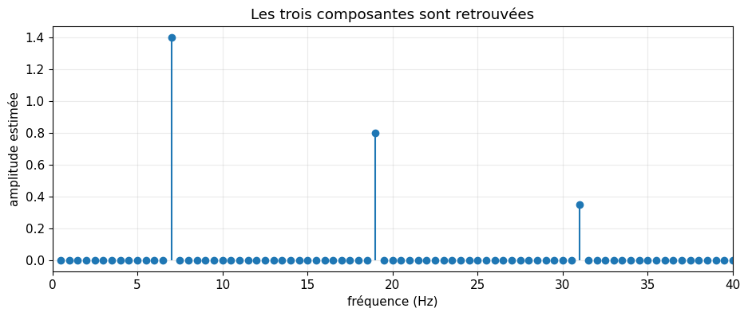

```python
fs_e1 = 256
t_e1 = np.arange(0, 2, 1/fs_e1)
x_e1 = (1.4*np.cos(2*np.pi*7*t_e1)
        + 0.8*np.sin(2*np.pi*19*t_e1)
        + 0.35*np.cos(2*np.pi*31*t_e1))
f_e1, X_e1 = spectrum(x_e1, fs_e1)
positive = f_e1 > 0
fp, Ap = f_e1[positive], np.abs(X_e1[positive])
peaks, props = signal.find_peaks(Ap, height=0.1)
found_f = fp[peaks]
found_a = 2*Ap[peaks]
print(list(zip(found_f, np.round(found_a, 3))))
assert np.allclose(found_f, [7, 19, 31])
assert np.allclose(found_a, [1.4, 0.8, 0.35])
plt.stem(fp, 2*Ap, basefmt=" ")
plt.xlim(0, 40); plt.xlabel("fréquence (Hz)"); plt.ylabel("amplitude estimée")
plt.title("Les trois composantes sont retrouvées"); plt.show()
```

## Corrigé 2 — Translation et phase

```
Erreur sur le module : 7.11e-15
Erreur angulaire maximale : 5.96e-10 rad
```

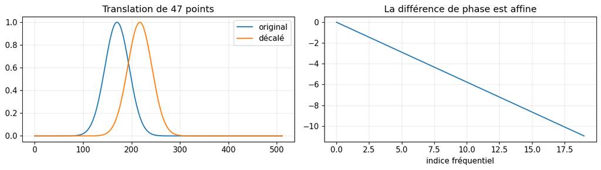

```python
N_e2, shift_e2 = 512, 47
n_e2 = np.arange(N_e2)
g_e2 = np.exp(-0.5*((n_e2-170)/25)**2)
g_shift_e2 = np.roll(g_e2, shift_e2)
G_e2 = np.fft.fft(g_e2)
Gs_e2 = np.fft.fft(g_shift_e2)
k_e2 = np.arange(N_e2)
theory_e2 = np.exp(-2j*np.pi*k_e2*shift_e2/N_e2)
mask_e2 = np.abs(G_e2) > 1e-6
module_error_e2 = np.max(np.abs(np.abs(G_e2)-np.abs(Gs_e2)))
phase_error_e2 = np.max(np.abs(np.angle((Gs_e2[mask_e2]/G_e2[mask_e2])/theory_e2[mask_e2])))
print(f"Erreur sur le module : {module_error_e2:.2e}")
print(f"Erreur angulaire maximale : {phase_error_e2:.2e} rad")
assert module_error_e2 < 1e-10 and phase_error_e2 < 1e-8
fig, ax = plt.subplots(1, 2, figsize=(12, 3.5))
ax[0].plot(g_e2, label="original"); ax[0].plot(g_shift_e2, label="décalé")
ax[0].legend(); ax[0].set_title("Translation de 47 points")
indices = np.flatnonzero(mask_e2 & (k_e2 < N_e2//2))
ax[1].plot(k_e2[indices], np.unwrap(np.angle(Gs_e2[indices]*np.conj(G_e2[indices]))))
ax[1].set_title("La différence de phase est affine"); ax[1].set_xlabel("indice fréquentiel")
plt.tight_layout(); plt.show()
```

## Corrigé 3 — Aliasing

```
{7: 7.0, 33: 7.0, 47: 7.0, 73: 7.0}
Écart maximal entre les quatre suites : 4.496403249731884e-14
```

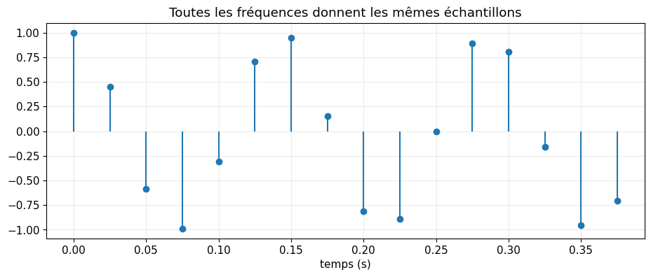

```python
fs_e3 = 40
freqs_e3 = np.array([7, 33, 47, 73])
aliases_e3 = np.abs((freqs_e3 + fs_e3/2) % fs_e3 - fs_e3/2)
t_e3 = np.arange(40)/fs_e3
samples_e3 = np.array([np.cos(2*np.pi*f*t_e3) for f in freqs_e3])
print(dict(zip(freqs_e3, aliases_e3)))
print("Écart maximal entre les quatre suites :", np.max(np.abs(samples_e3-samples_e3[0])))
assert np.allclose(aliases_e3, 7)
assert np.max(np.abs(samples_e3-samples_e3[0])) < 1e-12
plt.stem(t_e3[:16], samples_e3[0,:16], basefmt=" ")
plt.title("Toutes les fréquences donnent les mêmes échantillons")
plt.xlabel("temps (s)"); plt.show()
```

## Corrigé 4 — Deux portes inégales

```
Hauteur du plateau : 0.6 ; largeur : 0.7999999999999999
Erreur de discrétisation maximale : 2.000e-03
```

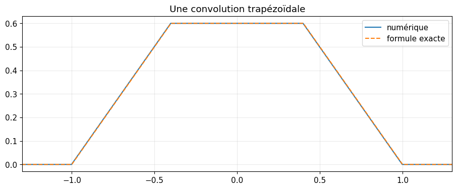

```python
dt_e4 = 0.002
t_e4 = np.arange(-2, 2+dt_e4, dt_e4)
a_e4, b_e4 = 0.6, 1.4
A_e4 = (np.abs(t_e4) <= a_e4/2).astype(float)
B_e4 = (np.abs(t_e4) <= b_e4/2).astype(float)
numeric_e4 = signal.fftconvolve(A_e4, B_e4, mode="same")*dt_e4
d_e4 = np.abs(t_e4)
exact_e4 = np.where(
    d_e4 <= abs(b_e4-a_e4)/2,
    min(a_e4, b_e4),
    np.maximum((a_e4+b_e4)/2-d_e4, 0),
)
error_e4 = np.max(np.abs(numeric_e4-exact_e4))
print(f"Hauteur du plateau : {min(a_e4,b_e4)} ; largeur : {abs(b_e4-a_e4)}")
print(f"Erreur de discrétisation maximale : {error_e4:.3e}")
assert error_e4 < 4*dt_e4
plt.plot(t_e4, numeric_e4, label="numérique")
plt.plot(t_e4, exact_e4, "--", label="formule exacte")
plt.xlim(-1.3, 1.3); plt.legend(); plt.title("Une convolution trapézoïdale")
plt.show()
```

## Corrigé 5 — Coupure à −3 dB

```
Coupure numérique : 4.224 Hz ; approximation : 4.219 Hz
```

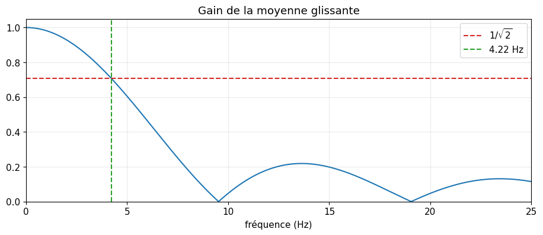

```python
fs_e5, m_e5, L_e5 = 200, 21, 2**16
h_e5 = np.ones(m_e5)/m_e5
f_e5 = np.fft.rfftfreq(L_e5, 1/fs_e5)
H_e5 = np.abs(np.fft.rfft(h_e5, L_e5))
cut_index_e5 = np.flatnonzero(H_e5 <= 1/np.sqrt(2))[0]
fc_e5 = f_e5[cut_index_e5]
approx_e5 = 0.443*fs_e5/m_e5
print(f"Coupure numérique : {fc_e5:.3f} Hz ; approximation : {approx_e5:.3f} Hz")
assert abs(fc_e5-approx_e5) < 0.15
plt.plot(f_e5, H_e5)
plt.axhline(1/np.sqrt(2), color="C3", ls="--", label=r"$1/\sqrt{2}$")
plt.axvline(fc_e5, color="C2", ls="--", label=f"{fc_e5:.2f} Hz")
plt.xlim(0, 25); plt.ylim(0, 1.05); plt.legend()
plt.xlabel("fréquence (Hz)"); plt.title("Gain de la moyenne glissante")
plt.show()
```

## Corrigé 6 — Filtrage d’un parasite

```
RMSE avant : 0.587 ; après : 0.030
```

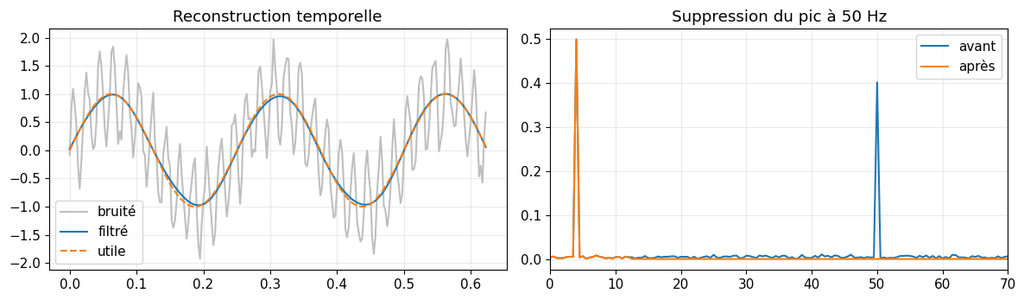

```python
fs_e6 = 400
t_e6 = np.arange(0, 2, 1/fs_e6)
useful_e6 = np.sin(2*np.pi*4*t_e6)
x_e6 = useful_e6 + 0.8*np.sin(2*np.pi*50*t_e6) + 0.15*rng.normal(size=len(t_e6))
f_e6 = np.fft.fftfreq(len(x_e6), 1/fs_e6)
X_e6 = np.fft.fft(x_e6)
mask_e6 = np.abs(f_e6) <= 12
y_e6 = np.fft.ifft(X_e6*mask_e6).real
rmse_before_e6 = np.sqrt(np.mean((x_e6-useful_e6)**2))
rmse_after_e6 = np.sqrt(np.mean((y_e6-useful_e6)**2))
print(f"RMSE avant : {rmse_before_e6:.3f} ; après : {rmse_after_e6:.3f}")
assert rmse_after_e6 < rmse_before_e6/4
fig, ax = plt.subplots(1, 2, figsize=(12, 3.6))
ax[0].plot(t_e6[:250], x_e6[:250], color="0.75", label="bruité")
ax[0].plot(t_e6[:250], y_e6[:250], label="filtré")
ax[0].plot(t_e6[:250], useful_e6[:250], "--", label="utile")
ax[0].legend(); ax[0].set_title("Reconstruction temporelle")
pos = f_e6 >= 0
ax[1].plot(f_e6[pos], np.abs(X_e6[pos])/len(x_e6), label="avant")
ax[1].plot(f_e6[pos], np.abs(X_e6[pos]*mask_e6[pos])/len(x_e6), label="après")
ax[1].set_xlim(0, 70); ax[1].legend(); ax[1].set_title("Suppression du pic à 50 Hz")
plt.tight_layout(); plt.show()
```

## Corrigé 7 — Padding et convolution circulaire

```
Taille minimale : 78; énergie revenue au début : 0.533
```

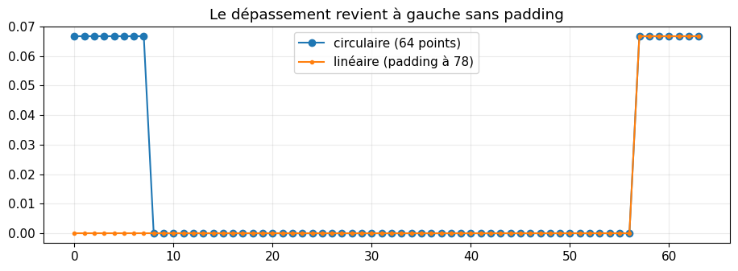

```python
N_e7, M_e7 = 64, 15
x_e7 = np.zeros(N_e7); x_e7[57] = 1
h_e7 = np.ones(M_e7)/M_e7
circular_e7 = np.fft.ifft(np.fft.fft(x_e7)*np.fft.fft(h_e7, N_e7)).real
L_e7 = N_e7 + M_e7 - 1
linear_e7 = np.fft.ifft(np.fft.fft(x_e7, L_e7)*np.fft.fft(h_e7, L_e7)).real
wrap_energy_e7 = np.sum(np.abs(circular_e7[:8]))
print(f"Taille minimale : {L_e7}; énergie revenue au début : {wrap_energy_e7:.3f}")
assert wrap_energy_e7 > 0.4
fig, ax = plt.subplots(figsize=(11, 3.5))
ax.plot(circular_e7, "o-", label="circulaire (64 points)")
ax.plot(linear_e7[:N_e7], ".-", label="linéaire (padding à 78)")
ax.legend(); ax.set_title("Le dépassement revient à gauche sans padding")
plt.show()
```

## Corrigé 8 — Détection par corrélation

```
Position réelle : 117; estimée : 117
```

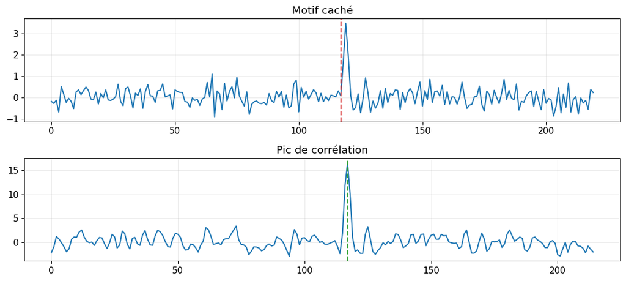

```python
pattern_e8 = np.array([0, 1, 3, 2, 0, -1.0])
position_e8 = 117
x_e8 = 0.45*rng.normal(size=220)
x_e8[position_e8:position_e8+len(pattern_e8)] += pattern_e8
corr_e8 = signal.correlate(x_e8, pattern_e8, mode="valid")
estimated_e8 = int(np.argmax(corr_e8))
print(f"Position réelle : {position_e8}; estimée : {estimated_e8}")
assert estimated_e8 == position_e8
fig, ax = plt.subplots(2, 1, figsize=(11, 5))
ax[0].plot(x_e8); ax[0].axvline(position_e8, color="C3", ls="--")
ax[0].set_title("Motif caché")
ax[1].plot(corr_e8); ax[1].axvline(estimated_e8, color="C2", ls="--")
ax[1].set_title("Pic de corrélation")
plt.tight_layout(); plt.show()
```

## Corrigé 9 — Image : lissage puis contours

```
RMSE bruitée : 0.220; lissée : 0.086
```

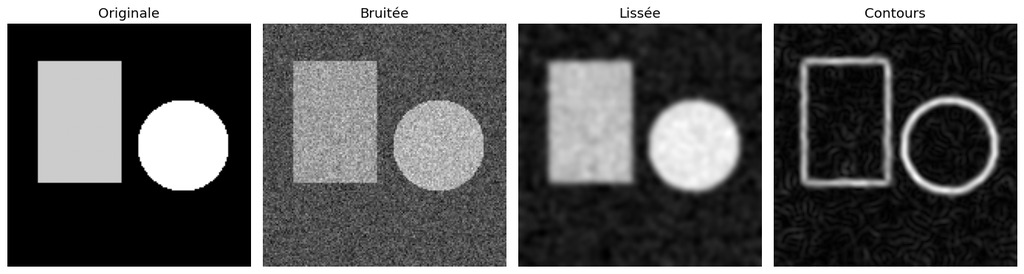

```python
N_e9 = 160
clean_e9 = np.zeros((N_e9, N_e9))
clean_e9[25:105, 20:75] = 0.8
yy_e9, xx_e9 = np.mgrid[:N_e9, :N_e9]
clean_e9[(xx_e9-115)**2 + (yy_e9-80)**2 < 30**2] = 1
noisy_e9 = clean_e9 + 0.22*rng.normal(size=clean_e9.shape)
g1_e9 = signal.windows.gaussian(11, std=2)
kernel_e9 = np.outer(g1_e9, g1_e9); kernel_e9 /= kernel_e9.sum()
smooth_e9 = convolve2d(noisy_e9, kernel_e9, mode="reflect")
sx_e9 = np.array([[-1,0,1],[-2,0,2],[-1,0,1]])
grad_e9 = np.hypot(
    convolve2d(smooth_e9, sx_e9, mode="reflect"),
    convolve2d(smooth_e9, sx_e9.T, mode="reflect"),
)
rmse_noisy_e9 = np.sqrt(np.mean((noisy_e9-clean_e9)**2))
rmse_smooth_e9 = np.sqrt(np.mean((smooth_e9-clean_e9)**2))
print(f"RMSE bruitée : {rmse_noisy_e9:.3f}; lissée : {rmse_smooth_e9:.3f}")
assert rmse_smooth_e9 < rmse_noisy_e9
fig, axes = plt.subplots(1, 4, figsize=(14, 3.7))
for ax, data, title in zip(axes, [clean_e9, noisy_e9, smooth_e9, grad_e9],
                            ["Originale", "Bruitée", "Lissée", "Contours"]):
    ax.imshow(data, cmap="gray"); ax.set_title(title); ax.axis("off")
plt.tight_layout(); plt.show()
```

## Corrigé 10 — Déconvolution régularisée

```
RMSE inversion naïve : 8.00e+07
RMSE régularisée : 0.060
```

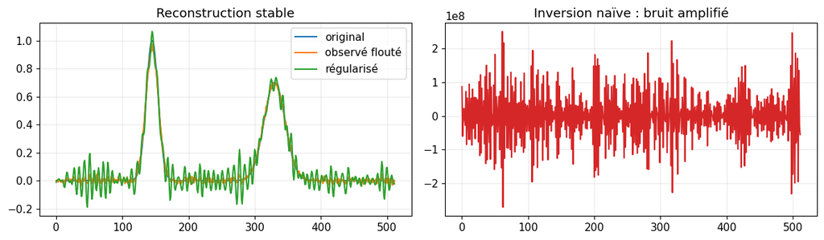

```python
N_e10 = 512
n_e10 = np.arange(N_e10)
x_e10 = (np.exp(-0.5*((n_e10-145)/9)**2)
         + 0.7*np.exp(-0.5*((n_e10-330)/16)**2))
f_e10 = np.fft.fftfreq(N_e10)
H_e10 = np.exp(-(np.abs(f_e10)/0.075)**2)
X_e10 = np.fft.fft(x_e10)
y_clean_e10 = np.fft.ifft(H_e10*X_e10).real
noise_e10 = 0.015*rng.normal(size=N_e10)
y_e10 = y_clean_e10 + noise_e10
Y_e10 = np.fft.fft(y_e10)
naive_e10 = np.fft.ifft(Y_e10/np.maximum(H_e10, 1e-10)).real
lambda_e10 = 1e-3
regularized_e10 = np.fft.ifft(np.conj(H_e10)*Y_e10/(np.abs(H_e10)**2+lambda_e10)).real
rmse_naive_e10 = np.sqrt(np.mean((naive_e10-x_e10)**2))
rmse_reg_e10 = np.sqrt(np.mean((regularized_e10-x_e10)**2))
print(f"RMSE inversion naïve : {rmse_naive_e10:.2e}")
print(f"RMSE régularisée : {rmse_reg_e10:.3f}")
assert rmse_reg_e10 < rmse_naive_e10/100
fig, ax = plt.subplots(1, 2, figsize=(12, 3.6))
ax[0].plot(x_e10, label="original")
ax[0].plot(y_e10, label="observé flouté")
ax[0].plot(regularized_e10, label="régularisé")
ax[0].legend(); ax[0].set_title("Reconstruction stable")
ax[1].plot(naive_e10, color="C3")
ax[1].set_title("Inversion naïve : bruit amplifié")
plt.tight_layout(); plt.show()
```

## Bilan des exercices

Ces exercices font apparaître les quatre usages essentiels :

- **analyser** un signal en séparant ses fréquences ;
- **prédire** les effets de l'échantillonnage et de la phase ;
- **filtrer** par convolution ou multiplication spectrale ;
- **inverser avec prudence**, car supprimer une fréquence détruit de l'information et rend la déconvolution instable.

# Carte mentale finale

| Dans le temps / l'espace | Dans les fréquences | Intuition |
| --- | --- | --- |
| somme de signaux | somme des spectres | linéarité |
| translation | multiplication par une phase | la phase code la position |
| dilatation | contraction du spectre | localisation ↔ étalement |
| convolution | multiplication | filtrer devient diagonal |
| multiplication | convolution | fenêtrer étale les fréquences |
| signal réel | symétrie hermitienne | fréquences positives et négatives liées |
| Dirac | constante | toutes les fréquences à poids égal |
| constante | Dirac en fréquence zéro | composante continue |

## Les trois phrases à retenir

1. **Fourier sépare les échelles d'oscillation d'un signal.**
2. **La convolution mélange localement un signal avec un noyau.**
3. **Fourier transforme ce mélange en une simple multiplication fréquence par fréquence.**

Les graphiques précédents ne remplacent pas les hypothèses des théorèmes continus, mais ils fournissent une intuition robuste pour les retrouver et les utiliser.